# Handout14Code_RMarkdown_studentsANSWERS

# Example 1: HandHeightFoot.xls

Import Data

```r
setwd(dirname(rstudioapi::getActiveDocumentContext()$path))
library(readxl)
HHFData=read_excel("HandHeightFoot.xls")
str(HHFData)
```

```
## tibble [29 × 4] (S3: tbl_df/tbl/data.frame)
##  $ Sex     : chr [1:29] "M" "M" "F" "F" ...
##  $ HandSpan: num [1:29] 22 22 20 19.5 19 ...
##  $ Height  : num [1:29] 71 66 65 67 68 68 73 64 74 73 ...
##  $ Footsize: num [1:29] 25 25.5 22 23 25 ...
```

```r
head(HHFData)
```

```
## # A tibble: 6 × 4
##   Sex   HandSpan Height Footsize
##   <chr>    <dbl>  <dbl>    <dbl>
## 1 M         22       71     25
## 2 M         22       66     25.5
## 3 F         20       65     22
## 4 F         19.5     67     23
## 5 F         19       68     25
## 6 M         19.5     68     24.8
```

```r
class(HHFData$Sex)
```

```
## [1] "character"
```

Change Sex to type Factor

```r
HHFData$Sex=factor(HHFData$Sex)
head(HHFData)
```

```
## # A tibble: 6 × 4
##   Sex   HandSpan Height Footsize
##   <fct>    <dbl>  <dbl>    <dbl>
## 1 M         22       71     25
## 2 M         22       66     25.5
## 3 F         20       65     22
## 4 F         19.5     67     23
## 5 F         19       68     25
## 6 M         19.5     68     24.8
```

```r
class(HHFData$Sex)
```

```
## [1] "factor"
```

```r
str(HHFData)
```

```
## tibble [29 × 4] (S3: tbl_df/tbl/data.frame)
##  $ Sex     : Factor w/ 2 levels "F","M": 2 2 1 1 1 2 2 1 2 2 ...
##  $ HandSpan: num [1:29] 22 22 20 19.5 19 ...
##  $ Height  : num [1:29] 71 66 65 67 68 68 73 64 74 73 ...
##  $ Footsize: num [1:29] 25 25.5 22 23 25 ...
```

### 1(a-b)

Coded scatter plot using symbols

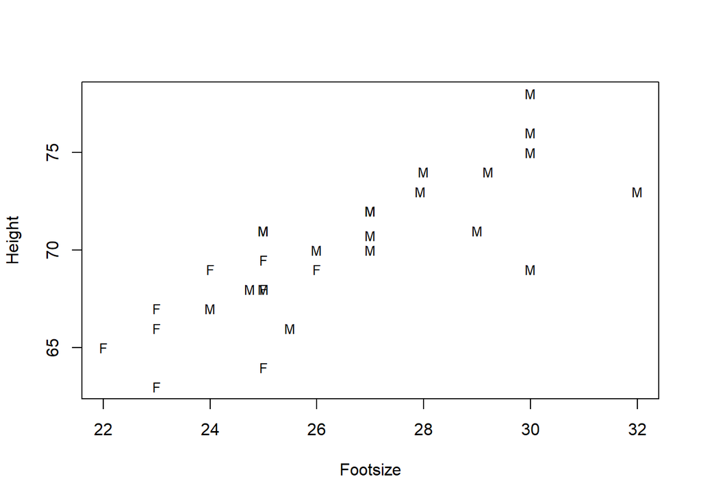

```r
plot(Height~Footsize, data=HHFData, pch=as.character(Sex),cex=0.8)
```

Regress height on foot size

```r
#mod1=lm(?????, data=HHFData)
#summary(mod1)

############ DELETE!!!!!!!!!!!!!
mod1=lm(Height~Footsize, data=HHFData)
summary(mod1)
```

```
##
## Call:
## lm(formula = Height ~ Footsize, data = HHFData)
##
## Residuals:
##     Min      1Q  Median      3Q     Max
## -5.0150 -0.5337  0.0959  1.3459  3.9850
##
## Coefficients:
##             Estimate Std. Error t value Pr(>|t|)
## (Intercept)  40.4056     4.2579   9.489 4.32e-10 ***
## Footsize      1.1203     0.1606   6.976 1.69e-07 ***
## ---
## Signif. codes:  0 '***' 0.001 '**' 0.01 '*' 0.05 '.' 0.1 ' ' 1
##
## Residual standard error: 2.187 on 27 degrees of freedom
## Multiple R-squared:  0.6432, Adjusted R-squared:   0.63
## F-statistic: 48.67 on 1 and 27 DF,  p-value: 1.692e-07
```

Color-coded scatter plot

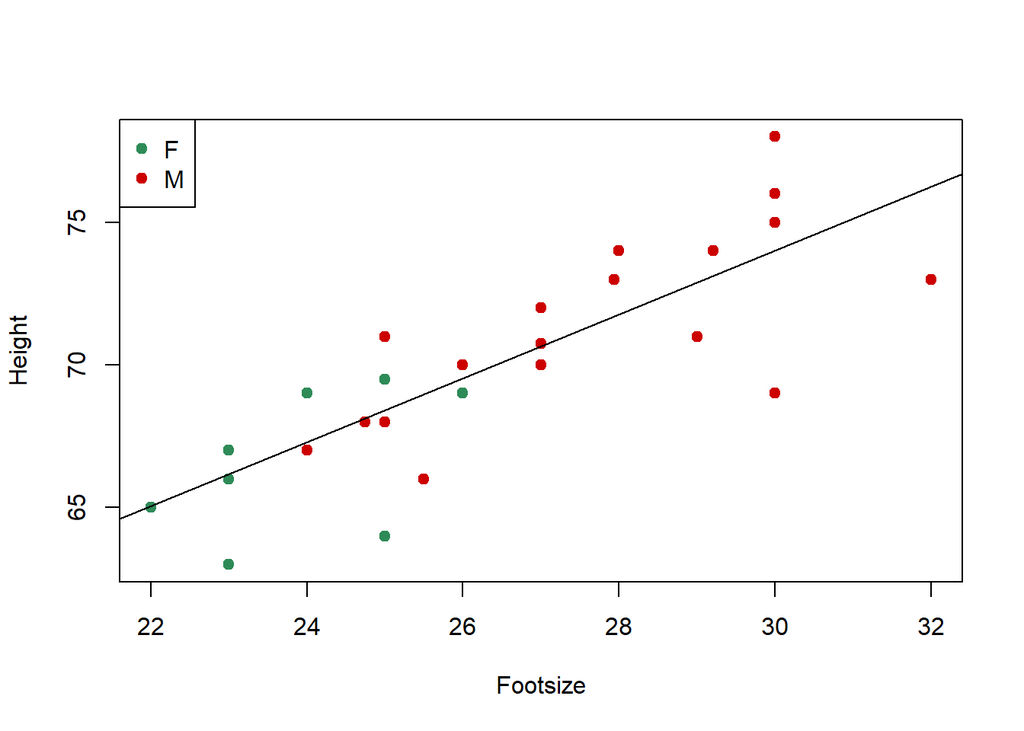

```r
#plot(?????, data=HHFData, col=c('seagreen','red3')[Sex],pch=19)
#legend('topleft',legend=levels(HHFData$Sex),pch=19,col=c('seagreen','red3'))
#abline(????,col='black')


############ DELETE!!!!!!!!!!!!!
plot(Height~Footsize, data=HHFData, col=c('seagreen','red3')[Sex],pch=19)
legend('topleft',legend=levels(HHFData$Sex),pch=19,col=c('seagreen','red3'))
abline(mod1,col='black')
```

### 1(c1)

Think what the plot would look like!  
Sketch it in the handout.

### 1(c2)

Code Sex 1=male, 0=female

```r
Sex.Coded=1*(HHFData$Sex=='M')
Sex.Coded
```

```
##  [1] 1 1 0 0 0 1 1 0 1 1 1 0 1 1 1 1 0 1 1 0 1 1 0 1 0 1 1 1 1
```

Scatterplot height vs. Sex.Coded

```r
plot(Height~Sex.Coded, data=HHFData,pch=19,col=c('seagreen','red3')[Sex.Coded+1])
abline(lm(Height~Sex.Coded, data=HHFData),col='black')
summary(lm(Height~Sex.Coded, data=HHFData))
```

```
##
## Call:
## lm(formula = Height ~ Sex.Coded, data = HHFData)
##
## Residuals:
##     Min      1Q  Median      3Q     Max
## -5.4375 -1.7222 -0.4375  2.2778  6.5625
##
## Coefficients:
##             Estimate Std. Error t value Pr(>|t|)
## (Intercept)  66.7222     0.9597   69.53  < 2e-16 ***
## Sex.Coded     4.7153     1.1556    4.08 0.000358 ***
## ---
## Signif. codes:  0 '***' 0.001 '**' 0.01 '*' 0.05 '.' 0.1 ' ' 1
##
## Residual standard error: 2.879 on 27 degrees of freedom
## Multiple R-squared:  0.3814, Adjusted R-squared:  0.3585
## F-statistic: 16.65 on 1 and 27 DF,  p-value: 0.0003576
```

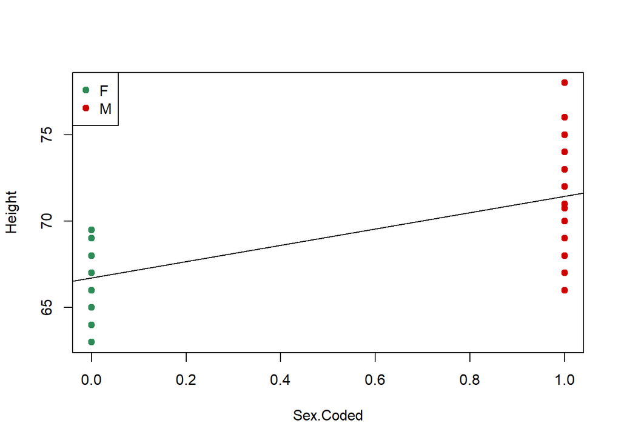

```r
#add legend
legend('topleft',legend=levels(HHFData$Sex),col=c('seagreen','red3'),pch=19)
```

### 1(d)

Regress height on footsize and Sex  
Contrasts(Sex)=c(0,1)

```r
###mod2=lm(????, data=HHFData)
###summary(???)



############ DELETE!!!!!!!!!!!!!
mod2=lm(Height~Footsize+Sex, data=HHFData)
summary(lm(Height~Footsize+Sex, data=HHFData))
```

```
##
## Call:
## lm(formula = Height ~ Footsize + Sex, data = HHFData)
##
## Residuals:
##     Min      1Q  Median      3Q     Max
## -4.8643 -1.0683  0.3186  1.2370  4.1357
##
## Coefficients:
##             Estimate Std. Error t value Pr(>|t|)
## (Intercept)  43.7014     4.9939   8.751 3.16e-09 ***
## Footsize      0.9592     0.2059   4.659 8.27e-05 ***
## SexM          1.3868     1.1253   1.232    0.229
## ---
## Signif. codes:  0 '***' 0.001 '**' 0.01 '*' 0.05 '.' 0.1 ' ' 1
##
## Residual standard error: 2.166 on 26 degrees of freedom
## Multiple R-squared:  0.6629, Adjusted R-squared:  0.6369
## F-statistic: 25.56 on 2 and 26 DF,  p-value: 7.268e-07
```

View coding [shows coding 0=F, 1=M]

```r
contrasts(HHFData$Sex)
```

```
##   M
## F 0
## M 1
```

Fitted line plot for each Sex

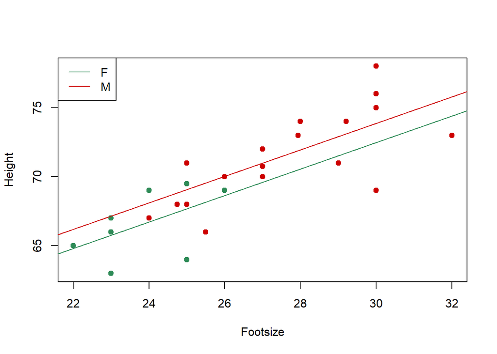

```r
coeff=mod2$coefficients
plot(Height~Footsize,data=HHFData,col=c('seagreen','red3')[Sex],pch=19)
abline(coeff[1],coeff[2],col='seagreen')
abline(coeff[1]+coeff[3],coeff[2],col='red3')
legend('topleft',legend=levels(HHFData$Sex),col=c('seagreen','red3'),lty=1)
```

### 1(e)

```r
model.matrix(lm(Height~Footsize+Sex, data=HHFData))
```

```
##    (Intercept) Footsize SexM
## 1            1    25.00    1
## 2            1    25.50    1
## 3            1    22.00    0
## 4            1    23.00    0
## 5            1    25.00    0
## 6            1    24.75    1
## 7            1    32.00    1
## 8            1    25.00    0
## 9            1    29.21    1
## 10           1    27.94    1
## 11           1    26.00    1
## 12           1    23.00    0
## 13           1    27.00    1
## 14           1    25.00    1
```

[output cut: 20 more lines]

```r
contrasts(HHFData$Sex)
```

```
##   M
## F 0
## M 1
```

### 1(f)

Change coding to -1=F, 1=M (sum coding)  
contr.treatment is the usual dummy (0,1) coding.  
We compare the intercepts of each level to the intercept of the reference level.  
In sum coding, we compare intercepts of each level to the “grand mean” of the intercepts.

```r
contrasts(HHFData$Sex)=c(-1,1)
contrasts(HHFData$Sex)
```

```
##   [,1]
## F   -1
## M    1
```

Regress height on footsize and Sex(-1=F, 1=M)

```r
#mod3=lm(???)
#summary(mod3)
#model.matrix(mod3)


############ DELETE!!!!!!!!!!!!!

mod3=lm(Height~Footsize+Sex,data=HHFData)
summary(mod3)
```

```
##
## Call:
## lm(formula = Height ~ Footsize + Sex, data = HHFData)
##
## Residuals:
##     Min      1Q  Median      3Q     Max
## -4.8643 -1.0683  0.3186  1.2370  4.1357
##
## Coefficients:
##             Estimate Std. Error t value Pr(>|t|)
## (Intercept)  44.3948     5.3165   8.350 7.84e-09 ***
## Footsize      0.9592     0.2059   4.659 8.27e-05 ***
## Sex1          0.6934     0.5626   1.232    0.229
## ---
## Signif. codes:  0 '***' 0.001 '**' 0.01 '*' 0.05 '.' 0.1 ' ' 1
##
## Residual standard error: 2.166 on 26 degrees of freedom
## Multiple R-squared:  0.6629, Adjusted R-squared:  0.6369
## F-statistic: 25.56 on 2 and 26 DF,  p-value: 7.268e-07
```

```r
model.matrix(mod3)
```

```
##    (Intercept) Footsize Sex1
## 1            1    25.00    1
## 2            1    25.50    1
## 3            1    22.00   -1
## 4            1    23.00   -1
## 5            1    25.00   -1
## 6            1    24.75    1
## 7            1    32.00    1
## 8            1    25.00   -1
## 9            1    29.21    1
## 10           1    27.94    1
## 11           1    26.00    1
## 12           1    23.00   -1
## 13           1    27.00    1
## 14           1    25.00    1
```

[output cut: 22 more lines]

Fitted line plot for each Sex

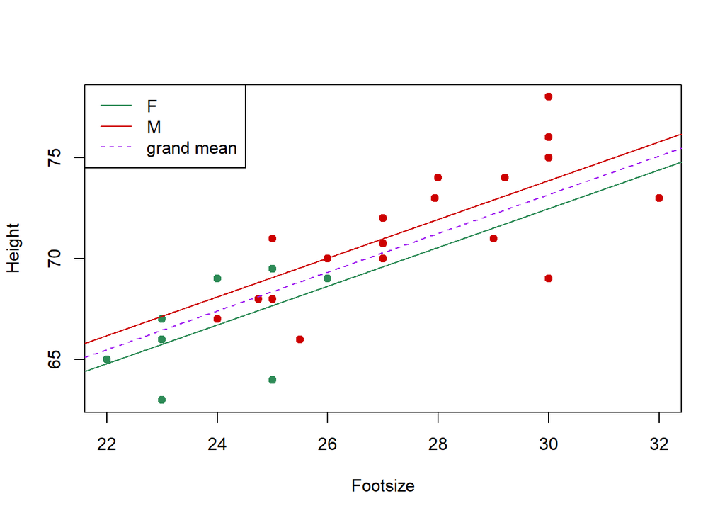

```r
coeff=mod3$coefficients
HHFData$Sex=relevel(HHFData$Sex,ref='F')
plot(Height~Footsize,data=HHFData,col=c('seagreen','red3')[Sex],pch=19)
abline(coeff[1]-coeff[3],coeff[2],col='seagreen')
abline(coeff[1]+coeff[3],coeff[2],col='red3')
legend('topleft',legend=c(levels(HHFData$Sex), "grand mean"),col=c('seagreen','red3','purple'),lty=c(1,1,2))
abline(coeff[1], coeff[2],lty=2,col='purple')
```

### 1(g-h)

Summary output

```r
summary(mod2)
```

```
##
## Call:
## lm(formula = Height ~ Footsize + Sex, data = HHFData)
##
## Residuals:
##     Min      1Q  Median      3Q     Max
## -4.8643 -1.0683  0.3186  1.2370  4.1357
##
## Coefficients:
##             Estimate Std. Error t value Pr(>|t|)
## (Intercept)  43.7014     4.9939   8.751 3.16e-09 ***
## Footsize      0.9592     0.2059   4.659 8.27e-05 ***
## SexM          1.3868     1.1253   1.232    0.229
## ---
## Signif. codes:  0 '***' 0.001 '**' 0.01 '*' 0.05 '.' 0.1 ' ' 1
##
## Residual standard error: 2.166 on 26 degrees of freedom
## Multiple R-squared:  0.6629, Adjusted R-squared:  0.6369
## F-statistic: 25.56 on 2 and 26 DF,  p-value: 7.268e-07
```

### 1(i)

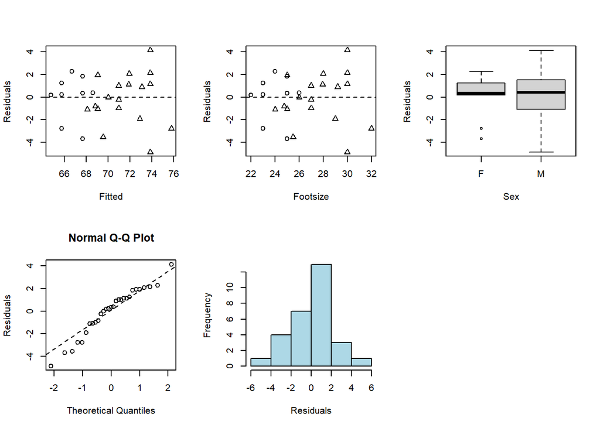

```r
par(mfrow=c(2,3))
plot(resid(mod2)~fitted(mod2),pch=as.numeric(Sex),xlab='Fitted', ylab='Residuals',data=HHFData); abline(h=0,lty=2)
plot(resid(mod2)~Footsize,pch=as.numeric(Sex),ylab='Residuals',data=HHFData); abline(h=0,lty=2)
plot(resid(mod2)~Sex,ylab='Residuals',data=HHFData)
qqnorm(resid(mod2),ylab='Residuals'); qqline(resid(mod2),lty=2)
hist(resid(mod2),main="", xlab="Residuals",col='lightblue')
par(mfrow=c(1,1))
```

# Example 2: fruitfly.xlsx

Import Data

```r
#setwd(dirname(rstudioapi::getActiveDocumentContext()$path))
#library(readxl)
fruitfly=read_excel("fruitfly.xlsx")
fruitfly$activity=factor(fruitfly$activity)
str(fruitfly)
```

```
## tibble [124 × 3] (S3: tbl_df/tbl/data.frame)
##  $ thorax   : num [1:124] 0.68 0.68 0.72 0.72 0.76 0.76 0.76 0.76 0.76 0.8 ...
##  $ longevity: num [1:124] 37 49 46 63 39 46 56 63 65 56 ...
##  $ activity : Factor w/ 5 levels "high","isolated",..: 4 4 4 4 4 4 4 4 4 4 ...
```

### 2(a-b)

Fit model: longevity ~ thorax+activity

```r
#fly.fit1 = lm(???)
#summary(fly.fit1)
#coeff = fly.fit1$coeff




############ DELETE!!!!!!!!!!!!!
fly.fit1 = lm(longevity ~ thorax+activity, fruitfly)
summary(fly.fit1)
```

```
##
## Call:
## lm(formula = longevity ~ thorax + activity, data = fruitfly)
##
## Residuals:
##     Min      1Q  Median      3Q     Max
## -26.108  -7.014  -1.101   6.234  30.265
##
## Coefficients:
##                  Estimate Std. Error t value Pr(>|t|)
## (Intercept)       -68.753     10.401  -6.610 1.17e-09 ***
## thorax            134.341     12.731  10.552  < 2e-16 ***
## activityisolated   20.004      3.016   6.632 1.05e-09 ***
## activitylow        12.989      3.019   4.302 3.51e-05 ***
## activitymany       24.142      3.016   8.005 9.38e-13 ***
## activityone        22.641      2.999   7.550 1.01e-11 ***
## ---
## Signif. codes:  0 '***' 0.001 '**' 0.01 '*' 0.05 '.' 0.1 ' ' 1
##
## Residual standard error: 10.54 on 118 degrees of freedom
## Multiple R-squared:  0.6527, Adjusted R-squared:  0.638
## F-statistic: 44.36 on 5 and 118 DF,  p-value: < 2.2e-16
```

```r
coeff = fly.fit1$coeff
```

Scatterplot with regression lines.

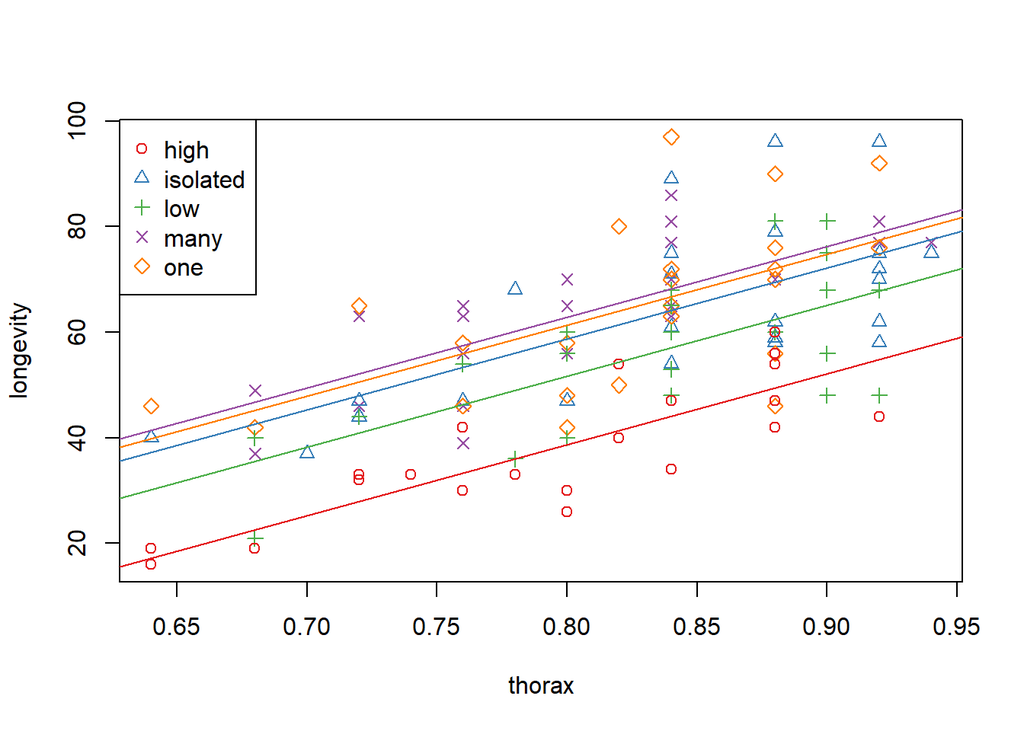

```r
par(mfrow=c(1,1))
#colors for coded scatter
library(RColorBrewer);cols <- brewer.pal(5, "Set1")
#colors for coded scatter
plot(longevity ~ thorax, fruitfly, pch=(1:5)[activity],col=cols[activity])
legend("topleft",legend=levels(fruitfly$activity),pch=1:5,col=cols)
#plot regression lines
for(i in 1:5){abline(coeff[1]+coeff[i+1]*(i>1),coeff[2],col=cols[i])}
```

### 2(c)

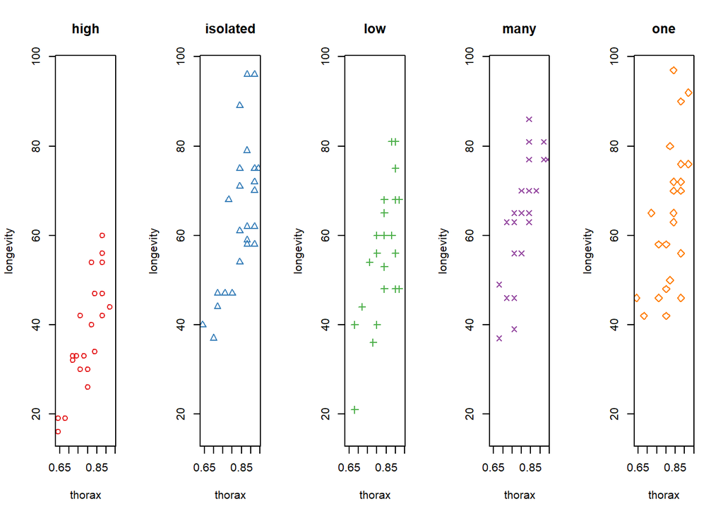

```r
par(mfrow=c(1,5))
for(i in 1:5){
  plot(longevity ~ thorax, data=fruitfly[fruitfly$activity==levels(fruitfly$activity)[i],],
     col=cols[i], ylab='longevity', xlab='thorax', main=levels(activity)[i],pch=i,
     xlim=range(fruitfly$thorax),ylim=range(fruitfly$longevity))
}
```

### 2(d)

#Residual diagnostics

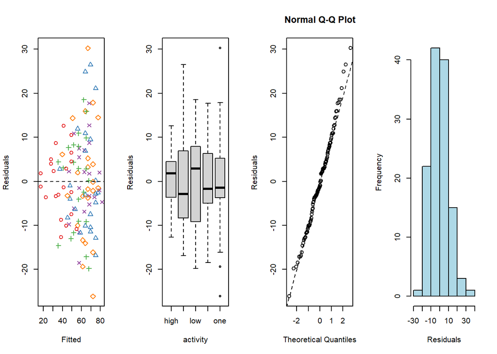

```r
par(mfrow=c(1,4))
plot(resid(fly.fit1)~fitted(fly.fit1),pch=(1:5)[fruitfly$activity], col=cols[activity],
     xlab='Fitted', ylab='Residuals',data=fruitfly); abline(h=0,lty=2)
plot(resid(fly.fit1)~activity,ylab='Residuals',data=fruitfly)
qqnorm(resid(fly.fit1),ylab='Residuals'); qqline(resid(fly.fit1),lty=2)
hist(resid(fly.fit1),main="", xlab="Residuals",col='lightblue')
```

### 2(e)

Model: log(longevity) ~ thorax+activity to remove heteroscedasticity

```r
#fly.fit2 = lm(??????)
#summary(fly.fit2)




############ DELETE!!!!!!!!!!!!!
fly.fit2 = lm(log(longevity) ~ thorax+activity, data=fruitfly)
summary(fly.fit2)
```

```
##
## Call:
## lm(formula = log(longevity) ~ thorax + activity, data = fruitfly)
##
## Residuals:
##      Min       1Q   Median       3Q      Max
## -0.52641 -0.13629 -0.00823  0.13918  0.39273
##
## Coefficients:
##                  Estimate Std. Error t value Pr(>|t|)
## (Intercept)       1.42496    0.19059   7.477 1.47e-11 ***
## thorax            2.72146    0.23329  11.666  < 2e-16 ***
## activityisolated  0.41925    0.05527   7.586 8.35e-12 ***
## activitylow       0.29538    0.05532   5.339 4.59e-07 ***
## activitymany      0.50716    0.05527   9.176 1.78e-15 ***
## activityone       0.47100    0.05495   8.571 4.62e-14 ***
## ---
## Signif. codes:  0 '***' 0.001 '**' 0.01 '*' 0.05 '.' 0.1 ' ' 1
##
## Residual standard error: 0.1931 on 118 degrees of freedom
## Multiple R-squared:  0.7025, Adjusted R-squared:  0.6899
## F-statistic: 55.72 on 5 and 118 DF,  p-value: < 2.2e-16
```

Residual diagnostics

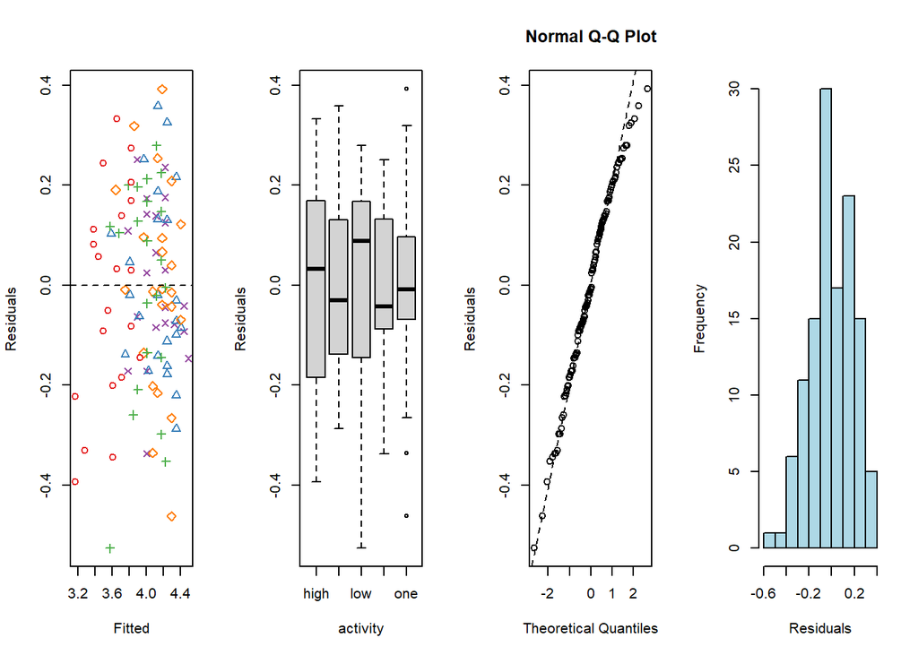

```r
par(mfrow=c(1,4))
plot(resid(fly.fit2)~fitted(fly.fit2),pch=(1:5)[fruitfly$activity], col=cols[activity],
     xlab='Fitted', ylab='Residuals',data=fruitfly); abline(h=0,lty=2)
plot(resid(fly.fit2)~activity,ylab='Residuals',data=fruitfly)
qqnorm(resid(fly.fit2),ylab='Residuals'); qqline(resid(fly.fit2),lty=2)
hist(resid(fly.fit2),main="", xlab="Residuals",col='lightblue')
```

### 2(f)

We can interpret the coefficients as having a multiplicative effect:

```r
exp(coef(fly.fit2)[3:6])
```

```
## activityisolated      activitylow     activitymany      activityone
##         1.520824         1.343643         1.660571         1.601589
```

### 2(g)

To see how the coding is done

```r
model.matrix(fly.fit2)
```

```
##     (Intercept) thorax activityisolated activitylow activitymany activityone
## 1             1   0.68                0           0            1           0
## 2             1   0.68                0           0            1           0
## 3             1   0.72                0           0            1           0
## 4             1   0.72                0           0            1           0
## 5             1   0.76                0           0            1           0
## 6             1   0.76                0           0            1           0
## 7             1   0.76                0           0            1           0
## 8             1   0.76                0           0            1           0
## 9             1   0.76                0           0            1           0
## 10            1   0.80                0           0            1           0
## 11            1   0.80                0           0            1           0
## 12            1   0.80                0           0            1           0
## 13            1   0.84                0           0            1           0
## 14            1   0.84                0           0            1           0
```

[output cut: 115 more lines]

### 2(h)

```r
library('car')
vif(lm(log(longevity) ~ thorax+activity, data=fruitfly))
```

```
##              GVIF Df GVIF^(1/(2*Df))
## thorax   1.037285  1        1.018472
## activity 1.037285  4        1.004586
```

```r
vif(lm(log(longevity) ~ thorax+activity, data=fruitfly))[,3]^2
```

```
##   thorax activity
## 1.037285 1.009194
```

### 2(i)

Advantage of thorax

```r
summary(lm(log(longevity) ~ thorax+activity, data=fruitfly))
```

```
##
## Call:
## lm(formula = log(longevity) ~ thorax + activity, data = fruitfly)
##
## Residuals:
##      Min       1Q   Median       3Q      Max
## -0.52641 -0.13629 -0.00823  0.13918  0.39273
##
## Coefficients:
##                  Estimate Std. Error t value Pr(>|t|)
## (Intercept)       1.42496    0.19059   7.477 1.47e-11 ***
## thorax            2.72146    0.23329  11.666  < 2e-16 ***
## activityisolated  0.41925    0.05527   7.586 8.35e-12 ***
## activitylow       0.29538    0.05532   5.339 4.59e-07 ***
## activitymany      0.50716    0.05527   9.176 1.78e-15 ***
## activityone       0.47100    0.05495   8.571 4.62e-14 ***
## ---
## Signif. codes:  0 '***' 0.001 '**' 0.01 '*' 0.05 '.' 0.1 ' ' 1
##
## Residual standard error: 0.1931 on 118 degrees of freedom
## Multiple R-squared:  0.7025, Adjusted R-squared:  0.6899
## F-statistic: 55.72 on 5 and 118 DF,  p-value: < 2.2e-16
```

```r
summary(lm(log(longevity) ~ activity, data=fruitfly))
```

```
##
## Call:
## lm(formula = log(longevity) ~ activity, data = fruitfly)
##
## Residuals:
##      Min       1Q   Median       3Q      Max
## -0.95531 -0.13187  0.03108  0.19814  0.49222
##
## Coefficients:
##                  Estimate Std. Error t value Pr(>|t|)
## (Intercept)       3.60212    0.05644  63.822  < 2e-16 ***
## activityisolated  0.51722    0.07982   6.480 2.17e-09 ***
## activitylow       0.39771    0.07982   4.983 2.15e-06 ***
## activitymany      0.54118    0.08065   6.711 6.95e-10 ***
## activityone       0.54067    0.07982   6.774 5.07e-10 ***
## ---
## Signif. codes:  0 '***' 0.001 '**' 0.01 '*' 0.05 '.' 0.1 ' ' 1
##
## Residual standard error: 0.2822 on 119 degrees of freedom
## Multiple R-squared:  0.3594, Adjusted R-squared:  0.3378
## F-statistic: 16.69 on 4 and 119 DF,  p-value: 6.963e-11
```

### 2(j-k)

Partial F-test manually

```r
#anova(lm(???))
#anova(lm(???))
#pf(

############ DELETE!!!!!!!!!!!!!
anova(lm(log(longevity) ~ thorax, data=fruitfly))
```

```
## Analysis of Variance Table
##
## Response: log(longevity)
##            Df Sum Sq Mean Sq F value    Pr(>F)
## thorax      1 6.2378  6.2378  88.951 3.416e-16 ***
## Residuals 122 8.5554  0.0701
## ---
## Signif. codes:  0 '***' 0.001 '**' 0.01 '*' 0.05 '.' 0.1 ' ' 1
```

```r
anova(lm(log(longevity) ~ thorax+activity, data=fruitfly))
```

```
## Analysis of Variance Table
##
## Response: log(longevity)
##            Df Sum Sq Mean Sq F value    Pr(>F)
## thorax      1 6.2378  6.2378 167.243 < 2.2e-16 ***
## activity    4 4.1542  1.0386  27.845 2.756e-16 ***
## Residuals 118 4.4012  0.0373
## ---
## Signif. codes:  0 '***' 0.001 '**' 0.01 '*' 0.05 '.' 0.1 ' ' 1
```

```r
pf(27.84,df1=4,df2=118,lower.tail = F)
```

```
## [1] 2.76988e-16
```

Partial F-test

```r
#anova(lm(???),
#      lm(???))



anova(lm(log(longevity) ~ thorax, data=fruitfly),
      lm(log(longevity) ~ thorax+activity, data=fruitfly))
```

```
## Analysis of Variance Table
##
## Model 1: log(longevity) ~ thorax
## Model 2: log(longevity) ~ thorax + activity
##   Res.Df    RSS Df Sum of Sq      F    Pr(>F)
## 1    122 8.5554
## 2    118 4.4012  4    4.1542 27.845 2.756e-16 ***
## ---
## Signif. codes:  0 '***' 0.001 '**' 0.01 '*' 0.05 '.' 0.1 ' ' 1
```

### 2(l)

Relevel low

```r
fruitfly$activity=relevel(fruitfly$activity, ref='low')
summary(lm(log(longevity) ~ thorax+activity, data=fruitfly))
```

```
##
## Call:
## lm(formula = log(longevity) ~ thorax + activity, data = fruitfly)
##
## Residuals:
##      Min       1Q   Median       3Q      Max
## -0.52641 -0.13629 -0.00823  0.13918  0.39273
##
## Coefficients:
##                  Estimate Std. Error t value Pr(>|t|)
## (Intercept)       1.72034    0.19918   8.637 3.25e-14 ***
## thorax            2.72146    0.23329  11.666  < 2e-16 ***
## activityhigh     -0.29538    0.05532  -5.339 4.59e-07 ***
## activityisolated  0.12387    0.05463   2.268 0.025176 *
## activitymany      0.21178    0.05550   3.816 0.000218 ***
## activityone       0.17561    0.05470   3.211 0.001706 **
## ---
## Signif. codes:  0 '***' 0.001 '**' 0.01 '*' 0.05 '.' 0.1 ' ' 1
##
## Residual standard error: 0.1931 on 118 degrees of freedom
## Multiple R-squared:  0.7025, Adjusted R-squared:  0.6899
## F-statistic: 55.72 on 5 and 118 DF,  p-value: < 2.2e-16
```